# Lab 1 – Review of R

## Class Introduction

Syllabus Link

Important notes:

- Attendance is important. Please let me know all days that you will miss ASAP so that I can better assign lab partners.
- Due Dates: Friday at 10pm (Homeworks), Saturday/Sunday at 10pm (labs/midterms)
- Course Schedule
- Teaching Philosophy
- Grade Matrix
- Tokens

## Class Format

Most classes will have the following format:

1. 5-10 minutes: Class announcements, preamble to lab (together)
2. Work on Lab (with partner)
3. 5-10 minutes: Class wrap up: reminder of goals/what you should have learned

Notes:

1. This semester I am experimenting with 1-2 labs per week that covers 2-3 days. I will try to give you an idea of how far you should get on each day.
2. We will only go over the preamble on the first day of a lab.
3. If you don’t finish the lab in class, you will need to finish them outside of class. You can either continue to work with your partner, or you can finish the lab on your own.

## Lab format

The “Lab” section is something you will work on with a partner using *paired programming*, a framework defined as follows:

- One partner is the driver, who physically writes code and operates the computer
- One partner is the navigator, who reviews the actions of the driver and provides feedback and guidance

Partners are encouraged to switch roles throughout the “Lab” section, but for the first few labs the less experienced coder should spend more time as the driver.

**Directions for all labs** (read before starting)

1. Please work together with your assigned partner (will not apply to first lab, just work with who you sit next to). Make sure you both fully understand something before moving on.
2. Record your answers to lab questions separately from the lab’s examples. You and your partner should only turn in responses to lab questions, nothing more and nothing less.
3. Ask for help, clarification, or even just a check-in if anything seems unclear.

# Preamble

Today’s preamble will be longer than usual in order to review important parts of R as a class.

## Goals

- Introduce the class and class format
- Refresh your memory of R and Rstudio
- Remind you of the differences between an R script and an R markdown file
- Introduce additional miscellaneous topics that will make working in R better
  - File paths
  - Basic Loops
  - Row Binding

## The Layout of R Studio

After you open `RStudio`, the first thing you’ll want to do is open a file to work in. You can do this by navigating: File -> New File -> RScript, which will open a new window in the top left of the `RStudio` interface for you to work in. At this point you should see four panels:

1. Your R Script (top left)
2. The Console (bottom left)
3. Your Environment (top right)
4. The Files/Plots/Help viewer (bottom right)

An *R Script* is like a text-file that stores your code while you work on it. At any point you can send some or all of the code in your *R Script* to the *Console* to execute. You can also type commands directly into the *Console*. The *Console* will echo any code you run, and it will display any textual/numeric output generated by your code.

The *Environment* shows you the names of data sets, variables, and user-created functions that have been loaded into your work space and can be accessed by your code. The *Files/Plots/Help Viewer* will display graphics generated by your code and a few other useful entities (like help documentation and file trees).

## Packages

To facilitate more complex tasks in `R`, many people have developed their own sets of functions known as *packages*. If you plan on working with a new package for the *first time*, it must be installed:

```r
install.packages("ggplot2", repos = "http://cran.us.r-project.org")
```

Once a package is installed, it still needs to be loaded into your R session using the `library()` function (or `require()`) before its contents can be used.

You’ll need to re-load a package *every time* you open `R Studio`, but you’ll only need to install it once.

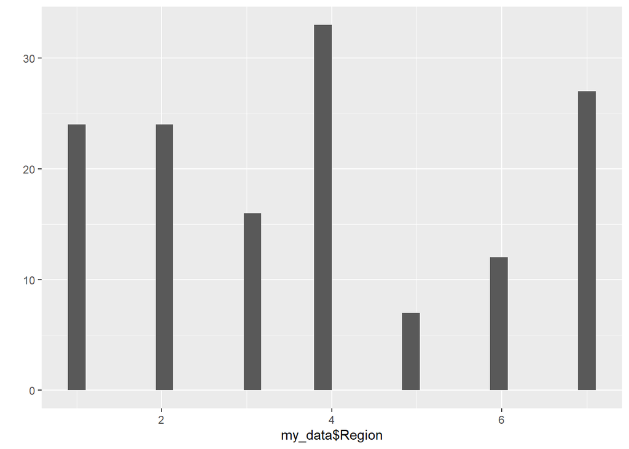

```r
my_data <- read.csv("https://remiller1450.github.io/data/HappyPlanet.csv")
library(ggplot2)
qplot(my_data$Region)
```

## R scripts vs R markdown

R Scripts are built to contain only executable `R` code and comments.

`R Studio` supports several other types of files, some of which use the “Markdown” authoring framework. An “R Markdown” file allows you to both:

1. Write and execute `R` code
2. Generate a high quality, reproducible report

To use R Markdown, you’ll need the `rmarkdown` package. In order to knit to pdf instead of html, you will likely need the tinytex package:

```r
install.packages("rmarkdown")
library("rmarkdown")
install.packages("tinytex")
tinytex::install_tinytex()
```

Once you have the package installed and loaded, you can create a new R Markdown file by selecting: File -> New File -> R Markdown.

At the top of the document is the **header**:

- This section initiated by three ‘-’ characters and closed by another three ‘-’ characters
- It contains the title, author, etc. that appears at the top of the document created by your code
- You can use it to add elements like a table of contents, page numbers, etc.

The second thing you’ll see is a **code chunk**:

- Code chunks are initiated by **```{r}** and closed by **```**
- The **```** wrappers tell R Markdown that what appears inside is code that should be executed. The first code chunk, initiated by **```{r setup}** sets up options that will be used in executing your `R` code when your report is built. For now, you should keep this chunk as it appears and place your actual code inside of other code chunks.
- You can execute the `R` code in a chunk by clicking the small green arrow in the upper right corner. You can also highlight individual code pieces and execute them using *Ctrl-Enter*.

Next you’ll see **section headers**:

- Sections are created using strings of the # character.
- The number of # characters used determines the level (size) of the header.

Finally, R Markdown allows you to type **ordinary text** outside of code chunks. Thus, you can easily integrate written text into the same document as your code and its output.

The primary purpose of R Markdown is to create documents that blend R code, output, and text into a polished report. To generate this document you must compile your R Markdown file using the “Knit” button (a blue yarn ball icon) located towards the upper left part of your screen.

The R Markdown cheat sheet can be found here: https://raw.githubusercontent.com/rstudio/cheatsheets/main/rmarkdown.pdf

**Question 0**: Create a new R Markdown file and delete all of the template code that appears beneath the “r setup” code block. Change the title to “Lab #1” and the author to your name(s). Next, create section labels for each question in the lab using three # characters followed by “Question X” (where X is the number of the question).

**Question 0 (continued)**: R Markdown will use LaTex typesetting for any text wrapped in $ characters. For example, $\beta$ will appear as a the Greek letter $\beta$ after you knit your document. To practice this, add a label for Question #1 and below it include $H_0: \mu = 0$ in a sentence (the sentence can say anything, but it should not be inside an R code chunk or a section header).

## Using R

`R` is an interpreted programming language, which allows you to have the computer execute any piece of code contained your *R Script* at any time without a lengthy compiling process.

To run a single piece of code, simply highlight it and either hit *Ctrl-Enter* or click on the “Run” button near the top right corner of your R Script. You should see an echo of the code you ran in the *Console*, along with any response generated by that code.

```r
4 + 6 - (24/6)
```

```
## [1] 6
```

```r
5 ^ 2 + 2 * 2
```

```
## [1] 29
```

The examples shown above demonstrate how `R` can be used as a calculator. However, most of code we will write will rely upon **functions**, or pre-built units of code that translate one or more *inputs* into one or more *outputs*.

```r
log(x = 4, base = 2)
```

```
## [1] 2
```

The example above demonstrates the `log()` function. The input named “x” is set to be 4, and the input named “base” is set to 2. The labels given to these inputs, “x” and “base”, are the function’s **arguments**. The function returns the output “2”, which is $\log_2{(4)}$. Note that `log(4, 2)` will also produce the output “2” as any unlabeled inputs are mapped to arguments in the order defined by the creator of the function.

## Help Documentation

You’ll eventually end up memorizing the arguments of common `R` functions; however, while you’re learning I strongly encourage you to read the *help documentation* for any `R` function used in your code. You can access a function’s documentation by typing a `?` in front of the function name and submitting to the console.

```r
?log
```

In addition, if you think there should be a function but you don’t know what it is called, you can use two ‘??’:

```r
??logarithm
```

## Adding Comments

When coding, it is good practice to include comments that describe what your code is doing. In `R` the character “#” is used to start a comment. Everything appearing on the same line to the right of the “#” will not be executed when that line is submitted to the console.

```r
# This entire line is a comment and will do nothing if run
```

```r
1:6 # The command "1:6" appears before this comment
```

```
## [1] 1 2 3 4 5 6
```

In your *R Script*, comments appear in green. You also should remember that the “#” starts a comment *only* for a single line of your R Script, so long comments requiring multiple lines should each begin with their own “#”.